# Biostat 203B Homework 5

Due Mar 22 @ 11:59PM

Author

Hanbei Xiong 605257780

```r
library(GGally)
library(gtsummary)
library(tidyverse)
library(tidymodels)
library(ranger)
library(stacks)
library(kernlab)
library(xgboost)
library(vip)
library(ggplot2)
```

## Predicting ICU duration

Using the ICU cohort `mimiciv_icu_cohort.rds` you built in Homework 4, develop at least three machine learning approaches (logistic regression with enet regularization, random forest, boosting, SVM, MLP, etc) plus a model stacking approach for predicting whether a patient’s ICU stay will be longer than 2 days. You should use the `los_long` variable as the outcome. You algorithms can use patient demographic information (gender, age at ICU `intime`, marital status, race), ICU admission information (first care unit), the last lab measurements before the ICU stay, and first vital measurements during ICU stay as features. You are welcome to use any feature engineering techniques you think are appropriate; but make sure to not use features that are not available at an ICU stay’s `intime`. For instance, `last_careunit` cannot be used in your algorithms.

1. Data preprocessing and feature engineering.

**Answer:**

We removed features that will not be used in this task. We also converted `los_long` to a factor variable so it can be used as the outcome variable in the model. We checked the distribution of the outcome variable and found that the data is relatively balanced.

```r
mimiciv_icu_cohort <- readRDS("./mimic_icu_cohort.rds")
```

```r
# Remove features that will not be used in this task
mimiciv_icu_cohort <- mimiciv_icu_cohort |>
  arrange(subject_id, hadm_id, stay_id) |>
  select(-c(subject_id, hadm_id, stay_id, last_careunit, intime, outtime,
            admittime, dischtime, deathtime, admit_provider_id,
            discharge_location, language, edregtime, edouttime, anchor_age,
            anchor_year, anchor_year_group, dod, hospital_expire_flag,
            admission_type, admission_location, insurance, los))
```

```r
mimiciv_icu_cohort <- mimiciv_icu_cohort |>
  mutate(los_long = ifelse(los_long == TRUE, 1, 0)) |>
  mutate(los_long = as.factor(los_long))
```

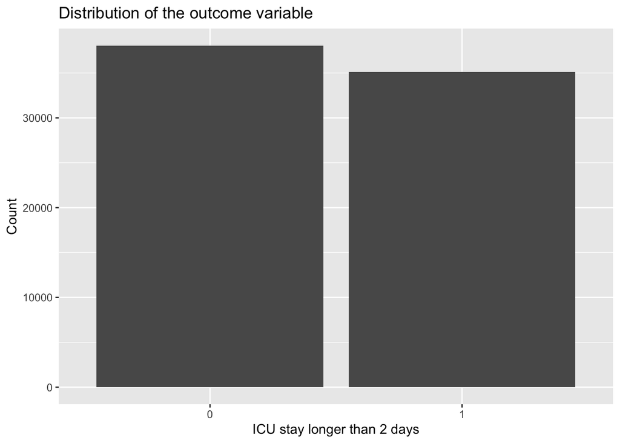

```r
# create a bar plot of the outcome variable
mimiciv_icu_cohort |>
  ggplot(aes(x = los_long)) +
  geom_bar() +
  labs(title = "Distribution of the outcome variable",
       x = "ICU stay longer than 2 days",
       y = "Count")
```

2. Partition data into 50% training set and 50% test set. Stratify partitioning according to `los_long`. For grading purpose, sort the data by `subject_id`, `hadm_id`, and `stay_id` and use the seed `203` for the initial data split. Below is the sample code.

**Answer:**

Data is split into 50% training set and 50% test set. The split is stratified according to `los_long`. The data has been sorted in the previous question.

```r
set.seed(203)

data_split <- initial_split(
  mimiciv_icu_cohort,
  # stratify by los_long
  strata = "los_long",
  prop = 0.5
  )
```

```r
data_split
```

```
<Training/Testing/Total>
<36590/36591/73181>
```

```r
other <- training(data_split)
dim(other)
```

```
[1] 36590    19
```

```r
test <- testing(data_split)
dim(test)
```

```
[1] 36591    19
```

3. Train and tune the models using the training set.

**Answer:** Three independent machine learning algorithms and one stacked model based on these three algorithms were tested in this section. We tuned parameters of each model on training set with 5 folds cross validation. The best set of parameters were selected based on the AUC score of model in each set of parameter. The entire workflow with the best set of parameters was applied to the test set to evaluate the performance of the model. Feature importance were extracted and reported at the end of each model.

# Logistic Regression

```r
# Impute the missing values and normalize the data
logit_recipe <-
  recipe(
    los_long ~ .,
    data = other
  ) |>
  step_impute_mean(Sodium) |>
  step_impute_mean(Glucose) |>
  step_impute_mean(Chloride) |>
  step_impute_mean(Potassium) |>
  step_impute_mean(Creatinine) |>
  step_impute_mean(Hematocrit) |>
  step_impute_mean(Bicarbonate) |>
  step_impute_mean(White_Blood_Cells) |>
  step_impute_mean(Heart_Rate) |>
  step_impute_mean(Respiratory_Rate) |>
  step_impute_mean(Temperature_Fahrenheit) |>
  step_impute_mean(Non_Invasive_Blood_Pressure_systolic) |>
  step_impute_mean(Non_Invasive_Blood_Pressure_diastolic) |>
  step_impute_mode(marital_status) |>
  step_dummy(all_nominal_predictors()) |>
  step_zv(all_numeric_predictors()) |>
  step_normalize(all_numeric_predictors()) |>
  print()
```

```
── Recipe ──────────────────────────────────────────────────────────────────────
```

```
── Inputs
```

```
Number of variables by role
```

```
outcome:    1
predictor: 18
```

```
── Operations
```

```
• Mean imputation for: Sodium
```

```
• Mean imputation for: Glucose
```

```
• Mean imputation for: Chloride
```

```
• Mean imputation for: Potassium
```

```
• Mean imputation for: Creatinine
```

```
• Mean imputation for: Hematocrit
```

```
• Mean imputation for: Bicarbonate
```

```
• Mean imputation for: White_Blood_Cells
```

```
• Mean imputation for: Heart_Rate
```

```
• Mean imputation for: Respiratory_Rate
```

```
• Mean imputation for: Temperature_Fahrenheit
```

```
• Mean imputation for: Non_Invasive_Blood_Pressure_systolic
```

```
• Mean imputation for: Non_Invasive_Blood_Pressure_diastolic
```

```
• Mode imputation for: marital_status
```

```
• Dummy variables from: all_nominal_predictors()
```

```
• Zero variance filter on: all_numeric_predictors()
```

```
• Centering and scaling for: all_numeric_predictors()
```

```r
# Define parameters to tune in later steps
logit_mod <-
  logistic_reg(
    penalty = tune(),
    mixture = tune()
  ) |>
  set_engine("glmnet", standardize = FALSE) |>
  print()
```

```
Logistic Regression Model Specification (classification)

Main Arguments:
  penalty = tune()
  mixture = tune()

Engine-Specific Arguments:
  standardize = FALSE

Computational engine: glmnet
```

```r
# Build workflow
logit_wf <- workflow() |>
  add_recipe(logit_recipe) |>
  add_model(logit_mod) |>
  print()
```

```
══ Workflow ════════════════════════════════════════════════════════════════════
Preprocessor: Recipe
Model: logistic_reg()

── Preprocessor ────────────────────────────────────────────────────────────────
17 Recipe Steps

• step_impute_mean()
• step_impute_mean()
• step_impute_mean()
• step_impute_mean()
• step_impute_mean()
• step_impute_mean()
• step_impute_mean()
• step_impute_mean()
• step_impute_mean()
• step_impute_mean()
• ...
• and 7 more steps.

── Model ───────────────────────────────────────────────────────────────────────
Logistic Regression Model Specification (classification)

Main Arguments:
  penalty = tune()
  mixture = tune()

Engine-Specific Arguments:
  standardize = FALSE

Computational engine: glmnet
```

```r
# Exhaustive grid search
param_grid <- grid_regular(
  penalty(range = c(-6, 3)),
  mixture(),
  levels = c(100, 5)
  )
```

```r
# 5 folds cross validation
set.seed(203)

folds <- vfold_cv(other, v = 5)
```

```r
# tuning using the grip search
(logit_fit <- logit_wf |>
  tune_grid(
    resamples = folds,
    grid = param_grid,
    control = control_grid(verbose = FALSE, save_pred = FALSE),
    metrics = metric_set(roc_auc, accuracy)
    )) |>
  system.time()
```

```
   user  system elapsed
 24.541   1.155  25.702
```

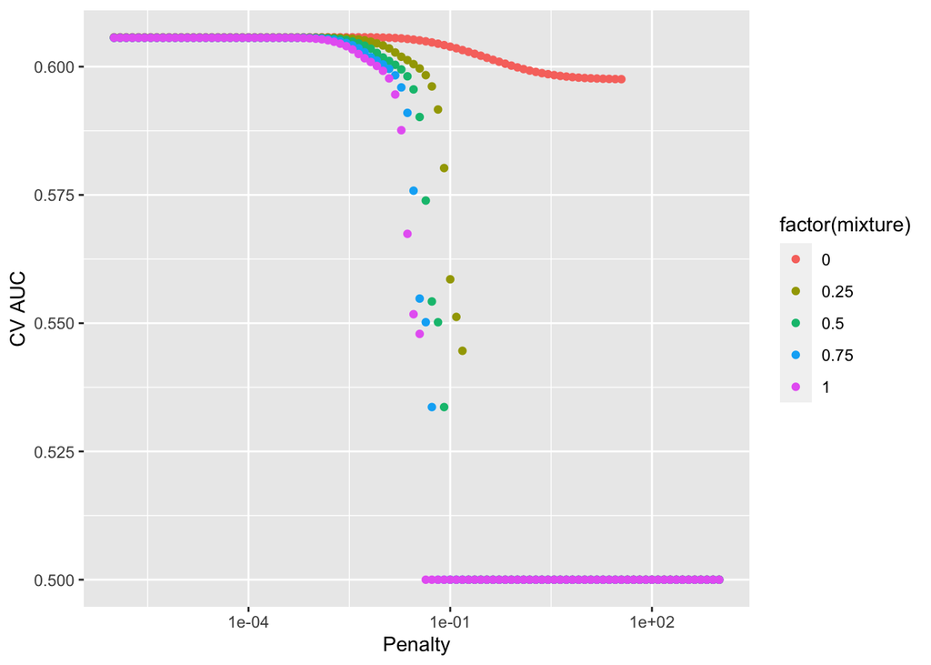

```r
# Plot to see how different combination of parameters perform
logit_fit |>
  # aggregate metrics from 3 folds
  collect_metrics() |>
  filter(.metric == "roc_auc") |>
  ggplot(mapping = aes(x = penalty, y = mean, color = factor(mixture))) +
  geom_point() +
  labs(x = "Penalty", y = "CV AUC") +
  scale_x_log10()
```

```r
# Show performance of model on training with different parameters
logit_fit |>
  show_best("roc_auc")
```

```
# A tibble: 5 × 8
     penalty mixture .metric .estimator  mean     n std_err .config
       <dbl>   <dbl> <chr>   <chr>      <dbl> <int>   <dbl> <chr>
1 0.000001         0 roc_auc binary     0.606     5 0.00281 Preprocessor1_Model…
2 0.00000123       0 roc_auc binary     0.606     5 0.00281 Preprocessor1_Model…
3 0.00000152       0 roc_auc binary     0.606     5 0.00281 Preprocessor1_Model…
4 0.00000187       0 roc_auc binary     0.606     5 0.00281 Preprocessor1_Model…
5 0.00000231       0 roc_auc binary     0.606     5 0.00281 Preprocessor1_Model…
```

```r
# Select the best model based on AUC
best_logit <- logit_fit |>
  select_best("roc_auc")
```

```r
# Finalize the workflow
final_wf_logit <- logit_wf |>
  finalize_workflow(best_logit)
```

```r
# Apply the workflow to the test set and collect AUC/Accuracy
final_fit_logit <-
  final_wf_logit |>
  last_fit(data_split)

final_fit_logit |>
  collect_metrics()
```

```
# A tibble: 2 × 4
  .metric  .estimator .estimate .config
  <chr>    <chr>          <dbl> <chr>
1 accuracy binary         0.575 Preprocessor1_Model1
2 roc_auc  binary         0.596 Preprocessor1_Model1
```

```r
# Here is the parameter estimates of the logistic regression model
final_model <- extract_fit_parsnip(final_fit_logit)
coefficients <- tidy(final_model)
print(coefficients)
```

```
# A tibble: 28 × 3
   term              estimate  penalty
   <chr>                <dbl>    <dbl>
 1 (Intercept)       -0.0802  0.000001
 2 Sodium             0.0775  0.000001
 3 Glucose            0.0147  0.000001
 4 Chloride          -0.0924  0.000001
 5 Potassium          0.0384  0.000001
 6 Creatinine         0.0447  0.000001
 7 Hematocrit        -0.128   0.000001
 8 Bicarbonate        0.00221 0.000001
 9 White_Blood_Cells  0.116   0.000001
10 Heart_Rate         0.170   0.000001
# ℹ 18 more rows
```

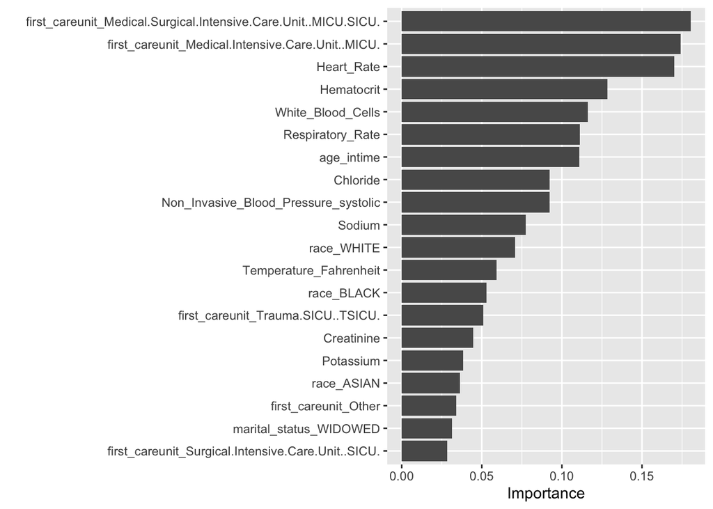

```r
# Show feature importance
vip(final_model, num_features = 20, method = "model")
```

**Summary:** The AUC is 0.596 and the accuracy is 0.575 on the test set. The most important features with relative similar importance are ‘first care units’ and ‘heart rate’.

# Random Forest

```r
# Impute the missing values and normalize the data
rf_recipe <-
  recipe(
    los_long ~ .,
    data = other
  ) |>
  step_impute_mean(Sodium) |>
  step_impute_mean(Glucose) |>
  step_impute_mean(Chloride) |>
  step_impute_mean(Potassium) |>
  step_impute_mean(Creatinine) |>
  step_impute_mean(Hematocrit) |>
  step_impute_mean(Bicarbonate) |>
  step_impute_mean(White_Blood_Cells) |>
  step_impute_mean(Heart_Rate) |>
  step_impute_mean(Respiratory_Rate) |>
  step_impute_mean(Temperature_Fahrenheit) |>
  step_impute_mean(Non_Invasive_Blood_Pressure_systolic) |>
  step_impute_mean(Non_Invasive_Blood_Pressure_diastolic) |>
  step_impute_mode(marital_status) |>
  step_zv(all_numeric_predictors()) |>
  print()
```

```
── Recipe ──────────────────────────────────────────────────────────────────────
```

```
── Inputs
```

```
Number of variables by role
```

```
outcome:    1
predictor: 18
```

```
── Operations
```

```
• Mean imputation for: Sodium
```

```
• Mean imputation for: Glucose
```

```
• Mean imputation for: Chloride
```

```
• Mean imputation for: Potassium
```

```
• Mean imputation for: Creatinine
```

```
• Mean imputation for: Hematocrit
```

```
• Mean imputation for: Bicarbonate
```

```
• Mean imputation for: White_Blood_Cells
```

```
• Mean imputation for: Heart_Rate
```

```
• Mean imputation for: Respiratory_Rate
```

```
• Mean imputation for: Temperature_Fahrenheit
```

```
• Mean imputation for: Non_Invasive_Blood_Pressure_systolic
```

```
• Mean imputation for: Non_Invasive_Blood_Pressure_diastolic
```

```
• Mode imputation for: marital_status
```

```
• Zero variance filter on: all_numeric_predictors()
```

```r
# Define parameters to tune in later steps
rf_mod <-
  rand_forest(
    mode = "classification",
    mtry = tune(),
    min_n = tune(),
    # tree can be a tuning parameter but it seems like the more trees in the
    # model, the better performance it will be. Therefore, we fix the amount
    # of tree for this task
    trees = 1000
  ) |>
  set_engine("ranger", importance = "impurity") |>
  set_mode("classification")
rf_mod
```

```
Random Forest Model Specification (classification)

Main Arguments:
  mtry = tune()
  trees = 1000
  min_n = tune()

Engine-Specific Arguments:
  importance = impurity

Computational engine: ranger
```

```r
# Build workflow
rf_wf <- workflow() |>
  add_recipe(rf_recipe) |>
  add_model(rf_mod)
```

```r
# Exhaustive grid search
rf_param_grid <- grid_regular(
  min_n(range = c(10, 100)),
  mtry(range = c(1L, 5L)),
  levels = c(3, 3)
  )
```

```r
# 5 folds cross validation
set.seed(203)

folds <- vfold_cv(other, v = 5)
```

```r
# tuning using the grip search
(rf_fit <- rf_wf |>
  tune_grid(
    resamples = folds,
    grid = rf_param_grid,
    metrics = metric_set(roc_auc, accuracy),
    control = control_grid(verbose = FALSE, save_pred = FALSE),
    )) |>
  system.time()
```

```
   user  system elapsed
788.586  15.900 599.642
```

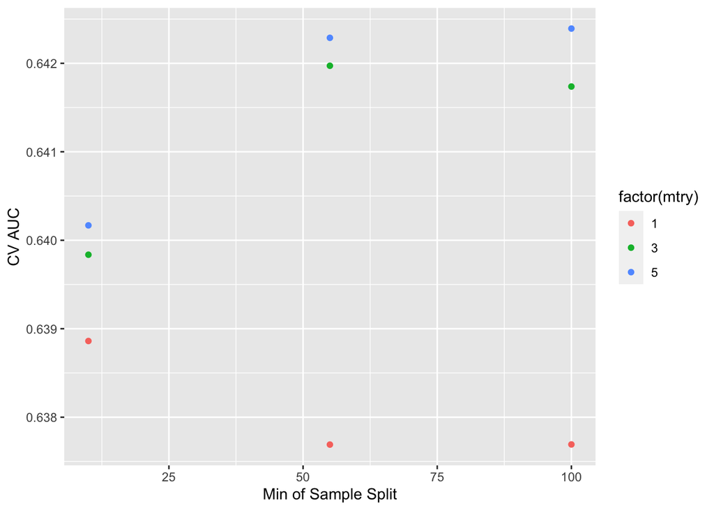

```r
# Plot to see how different combination of parameters perform
rf_fit |>
  collect_metrics() |>
  # print(width = Inf) |>
  filter(.metric == "roc_auc") |>
  ggplot(mapping = aes(x = min_n, y = mean, color = factor(mtry))) +
  geom_point() +
  # geom_line() +
  labs(x = "Min of Sample Split", y = "CV AUC")
```

```r
# Show performance of model on training with different parameters
rf_fit |>
  show_best("roc_auc")
```

```
# A tibble: 5 × 8
   mtry min_n .metric .estimator  mean     n std_err .config
  <int> <int> <chr>   <chr>      <dbl> <int>   <dbl> <chr>
1     5   100 roc_auc binary     0.642     5 0.00353 Preprocessor1_Model9
2     5    55 roc_auc binary     0.642     5 0.00346 Preprocessor1_Model8
3     3    55 roc_auc binary     0.642     5 0.00353 Preprocessor1_Model5
4     3   100 roc_auc binary     0.642     5 0.00377 Preprocessor1_Model6
5     5    10 roc_auc binary     0.640     5 0.00395 Preprocessor1_Model7
```

```r
# Select the best model based on AUC
best_rf <- rf_fit |>
  select_best("roc_auc")
```

```r
# Finalize the workflow
final_wf_rf <- rf_wf |>
  finalize_workflow(best_rf)
```

```r
# Apply the workflow to the test set and collect AUC/Accuracy
final_fit_rf <-
  final_wf_rf |>
  last_fit(data_split)

final_fit_rf |>
  collect_metrics()
```

```
# A tibble: 2 × 4
  .metric  .estimator .estimate .config
  <chr>    <chr>          <dbl> <chr>
1 accuracy binary         0.601 Preprocessor1_Model1
2 roc_auc  binary         0.639 Preprocessor1_Model1
```

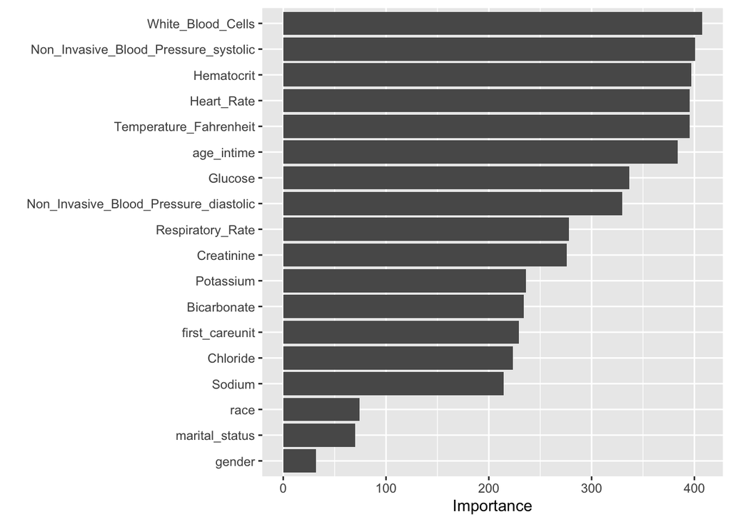

```r
# Show feature importance
final_fit_rf |>
  extract_fit_parsnip() |>
  vip(num_features = 20)
```

**Summary:** The AUC is 0.639 and the accuracy is 0.601 on the test set. The most important features with relative similar importance are ‘white blood cells’, ‘hematocrit’, ‘non invasive blood pressure systolic’, ‘heart rate’, and ‘temperature’.

# XGBoost

```r
# Impute the missing values and normalize the data
gb_recipe <-
  recipe(
    los_long ~ .,
    data = other
  ) |>
  step_impute_mean(Sodium) |>
  step_impute_mean(Glucose) |>
  step_impute_mean(Chloride) |>
  step_impute_mean(Potassium) |>
  step_impute_mean(Creatinine) |>
  step_impute_mean(Hematocrit) |>
  step_impute_mean(Bicarbonate) |>
  step_impute_mean(White_Blood_Cells) |>
  step_impute_mean(Heart_Rate) |>
  step_impute_mean(Respiratory_Rate) |>
  step_impute_mean(Temperature_Fahrenheit) |>
  step_impute_mean(Non_Invasive_Blood_Pressure_systolic) |>
  step_impute_mean(Non_Invasive_Blood_Pressure_diastolic) |>
  step_impute_mode(marital_status) |>
  step_dummy(all_nominal_predictors()) |>
  step_zv(all_numeric_predictors()) |>
  print()
```

```
── Recipe ──────────────────────────────────────────────────────────────────────
```

```
── Inputs
```

```
Number of variables by role
```

```
outcome:    1
predictor: 18
```

```
── Operations
```

```
• Mean imputation for: Sodium
```

```
• Mean imputation for: Glucose
```

```
• Mean imputation for: Chloride
```

```
• Mean imputation for: Potassium
```

```
• Mean imputation for: Creatinine
```

```
• Mean imputation for: Hematocrit
```

```
• Mean imputation for: Bicarbonate
```

```
• Mean imputation for: White_Blood_Cells
```

```
• Mean imputation for: Heart_Rate
```

```
• Mean imputation for: Respiratory_Rate
```

```
• Mean imputation for: Temperature_Fahrenheit
```

```
• Mean imputation for: Non_Invasive_Blood_Pressure_systolic
```

```
• Mean imputation for: Non_Invasive_Blood_Pressure_diastolic
```

```
• Mode imputation for: marital_status
```

```
• Dummy variables from: all_nominal_predictors()
```

```
• Zero variance filter on: all_numeric_predictors()
```

```r
# Define parameters to tune in later steps
gb_mod <-
  boost_tree(
    mode = "classification",
    trees = 1000,
    tree_depth = tune(),
    learn_rate = tune()
  ) |>
  set_engine("xgboost")
gb_mod
```

```
Boosted Tree Model Specification (classification)

Main Arguments:
  trees = 1000
  tree_depth = tune()
  learn_rate = tune()

Computational engine: xgboost
```

```r
# Build workflow
gb_wf <- workflow() |>
  add_recipe(gb_recipe) |>
  add_model(gb_mod)
gb_wf
```

```
══ Workflow ════════════════════════════════════════════════════════════════════
Preprocessor: Recipe
Model: boost_tree()

── Preprocessor ────────────────────────────────────────────────────────────────
16 Recipe Steps

• step_impute_mean()
• step_impute_mean()
• step_impute_mean()
• step_impute_mean()
• step_impute_mean()
• step_impute_mean()
• step_impute_mean()
• step_impute_mean()
• step_impute_mean()
• step_impute_mean()
• ...
• and 6 more steps.

── Model ───────────────────────────────────────────────────────────────────────
Boosted Tree Model Specification (classification)

Main Arguments:
  trees = 1000
  tree_depth = tune()
  learn_rate = tune()

Computational engine: xgboost
```

```r
# Exhaustive grid search
gb_param_grid <- grid_regular(
  tree_depth(range = c(1L, 3L)),
  learn_rate(range = c(-5, 2), trans = log10_trans()),
  levels = c(3, 3)
  )
```

```r
# 5 folds cross validation
set.seed(203)

folds <- vfold_cv(other, v = 5)
```

```r
# Tuning using the grip search
gb_fit <- gb_wf |>
  tune_grid(
    resamples = folds,
    grid = gb_param_grid,
    metrics = metric_set(roc_auc, accuracy),
    control = control_grid(verbose = FALSE, save_pred = FALSE)
    )
gb_fit
```

```
# Tuning results
# 5-fold cross-validation
# A tibble: 5 × 4
  splits               id    .metrics          .notes
  <list>               <chr> <list>            <list>
1 <split [29272/7318]> Fold1 <tibble [18 × 6]> <tibble [0 × 3]>
2 <split [29272/7318]> Fold2 <tibble [18 × 6]> <tibble [0 × 3]>
3 <split [29272/7318]> Fold3 <tibble [18 × 6]> <tibble [0 × 3]>
4 <split [29272/7318]> Fold4 <tibble [18 × 6]> <tibble [0 × 3]>
5 <split [29272/7318]> Fold5 <tibble [18 × 6]> <tibble [0 × 3]>
```

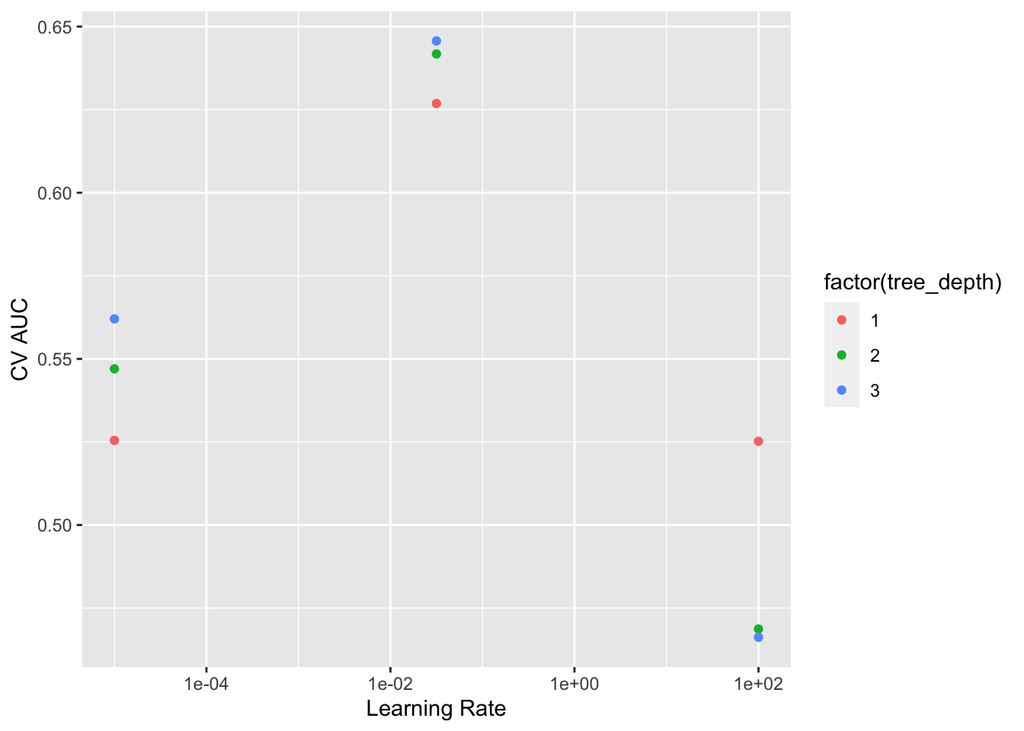

```r
# Plot to see how different combination of parameters perform
gb_fit |>
  collect_metrics() |>
  # print(width = Inf) |>
  filter(.metric == "roc_auc") |>
  ggplot(mapping = aes(x = learn_rate, y = mean, color = factor(tree_depth))) +
  geom_point() +
  labs(x = "Learning Rate", y = "CV AUC") +
  scale_x_log10()
```

```r
# Show performance of model on training with different parameters
best_gb <- gb_fit |>
  select_best("roc_auc")
```

```r
# Finalize the workflow
final_wf <- gb_wf |>
  finalize_workflow(best_gb)
```

```r
# Apply the workflow to the test set and collect AUC/Accuracy
final_fit <-
  final_wf |>
  last_fit(data_split)

final_fit |>
  collect_metrics()
```

```
# A tibble: 2 × 4
  .metric  .estimator .estimate .config
  <chr>    <chr>          <dbl> <chr>
1 accuracy binary         0.603 Preprocessor1_Model1
2 roc_auc  binary         0.645 Preprocessor1_Model1
```

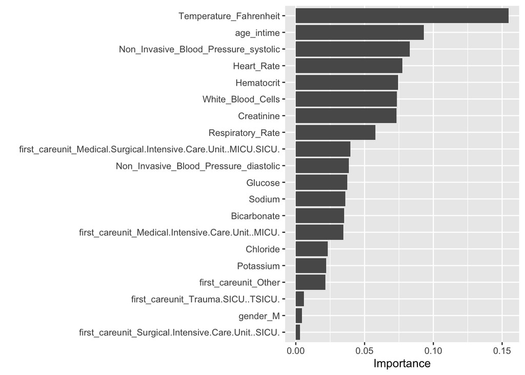

```r
# Show feature importance
final_fit |>
  extract_fit_parsnip() |>
  vip(num_features = 20)
```

**Summary:** The AUC is 0.645 and the accuracy is 0.603 on the test set. The most important feature is “Temperature”.

# Model Stacking

```r
# Impute the missing values and normalize the data
stack_recipe <-
  recipe(
    los_long ~ .,
    data = other
  ) |>
  step_impute_mean(Sodium) |>
  step_impute_mean(Glucose) |>
  step_impute_mean(Chloride) |>
  step_impute_mean(Potassium) |>
  step_impute_mean(Creatinine) |>
  step_impute_mean(Hematocrit) |>
  step_impute_mean(Bicarbonate) |>
  step_impute_mean(White_Blood_Cells) |>
  step_impute_mean(Heart_Rate) |>
  step_impute_mean(Respiratory_Rate) |>
  step_impute_mean(Temperature_Fahrenheit) |>
  step_impute_mean(Non_Invasive_Blood_Pressure_systolic) |>
  step_impute_mean(Non_Invasive_Blood_Pressure_diastolic) |>
  step_impute_mode(marital_status) |>
  step_dummy(all_nominal_predictors()) |>
  step_zv(all_numeric_predictors()) |>
  step_normalize(all_numeric_predictors()) |>
  print()
```

```
── Recipe ──────────────────────────────────────────────────────────────────────
```

```
── Inputs
```

```
Number of variables by role
```

```
outcome:    1
predictor: 18
```

```
── Operations
```

```
• Mean imputation for: Sodium
```

```
• Mean imputation for: Glucose
```

```
• Mean imputation for: Chloride
```

```
• Mean imputation for: Potassium
```

```
• Mean imputation for: Creatinine
```

```
• Mean imputation for: Hematocrit
```

```
• Mean imputation for: Bicarbonate
```

```
• Mean imputation for: White_Blood_Cells
```

```
• Mean imputation for: Heart_Rate
```

```
• Mean imputation for: Respiratory_Rate
```

```
• Mean imputation for: Temperature_Fahrenheit
```

```
• Mean imputation for: Non_Invasive_Blood_Pressure_systolic
```

```
• Mean imputation for: Non_Invasive_Blood_Pressure_diastolic
```

```
• Mode imputation for: marital_status
```

```
• Dummy variables from: all_nominal_predictors()
```

```
• Zero variance filter on: all_numeric_predictors()
```

```
• Centering and scaling for: all_numeric_predictors()
```

```r
# 5 folds cross validation
set.seed(203)
folds <- vfold_cv(other, v = 5)
```

```r
# Logistic Regression
logit_mod <-
  logistic_reg(
    penalty = tune(),
    mixture = tune()
  ) |>
  set_engine("glmnet", standardize = TRUE)

logit_wf <- workflow() |>
  add_recipe(stack_recipe) |>
  add_model(logit_mod)

logit_grid <- grid_regular(
  penalty(range = c(-6, 3)),
  mixture(),
  levels = c(5, 5)
  )

logit_res <-
  tune_grid(
    object = logit_wf,
    resamples = folds,
    grid = logit_grid,
    control = control_stack_grid()
  )
```

```r
# Random Forest
rf_mod <-
  rand_forest(
    mode = "classification",
    mtry = tune(),
    min_n = tune(),
    trees = 1000
  ) |>
  set_engine("ranger")

rf_wf <- workflow() |>
  add_recipe(stack_recipe) |>
  add_model(rf_mod)

rf_grid <- grid_regular(
  min_n(range = c(10, 100)),
  mtry(range = c(1L, 5L)),
  levels = c(3, 3)
  )

rf_res <-
  tune_grid(
    object = rf_wf,
    resamples = folds,
    grid = rf_grid,
    control = control_stack_grid()
  )
```

```r
# Gradient Boosting
gb_mod <-
  boost_tree(
    mode = "classification",
    trees = 1000,
    tree_depth = tune(),
    learn_rate = tune()
  ) |>
  set_engine("xgboost")

gb_wf <- workflow() |>
  add_recipe(stack_recipe) |>
  add_model(gb_mod)

gb_grid <- grid_regular(
  tree_depth(range = c(1L, 3L)),
  learn_rate(range = c(-5, 2), trans = log10_trans()),
  levels = c(3, 3)
  )

gb_res <-
  tune_grid(
    object = gb_wf,
    resamples = folds,
    grid = gb_grid,
    control = control_stack_grid()
    )
```

```r
# Stacking the three candidate models
(model_st <-
  # initialize the stack
  stacks() |>
  # add candidate members
  add_candidates(logit_res) |>
  add_candidates(rf_res) |>
  add_candidates(gb_res) |>
  # determine how to combine their predictions
  blend_predictions(
    penalty = 10^(-6:2),
    metrics = c("roc_auc")
    ) |>
  # fit the candidates with nonzero stacking coefficients
  fit_members()) |>
  system.time()
```

```
   user  system elapsed
157.076   1.752 158.903
```

```r
# Information of the members in stacked model
model_st
```

```
── A stacked ensemble model ─────────────────────────────────────


Out of 30 possible candidate members, the ensemble retained 5.

Penalty: 0.001.

Mixture: 1.


The 5 highest weighted member classes are:
```

```
# A tibble: 5 × 3
  member                 type         weight
  <chr>                  <chr>         <dbl>
1 .pred_1_rf_res_1_4     rand_forest  2.70
2 .pred_1_gb_res_1_6     boost_tree   2.63
3 .pred_1_logit_res_1_01 logistic_reg 0.0923
4 .pred_1_gb_res_1_9     boost_tree   0.0664
5 .pred_1_gb_res_1_8     boost_tree   0.0513
```

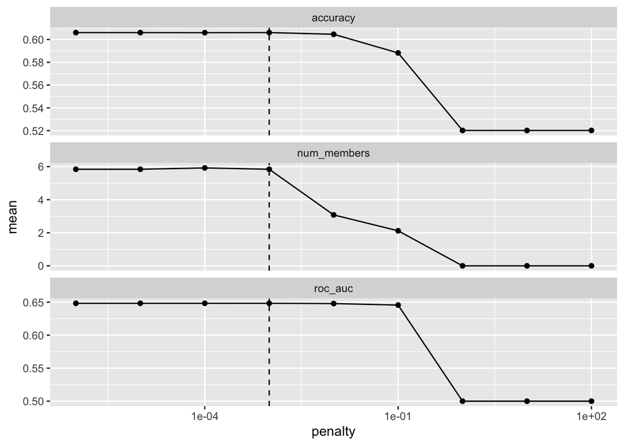

```r
# Plot to see how penalty changes the model performance
autoplot(model_st)
```

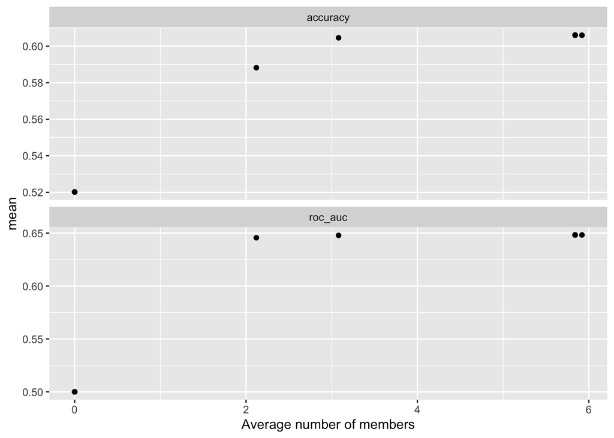

```r
# Plot to see how number of models in stacked model change the performance
autoplot(model_st, type = "members")
```

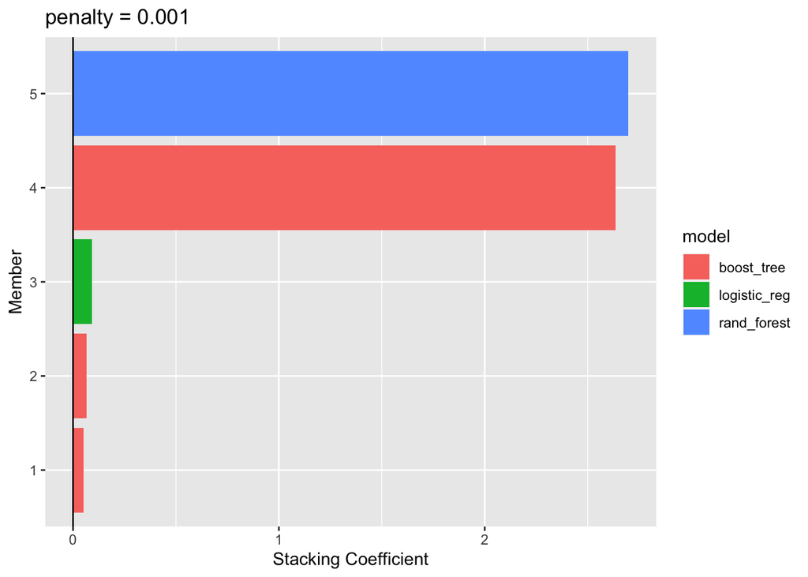

```r
# Plot to see how the weights of each model in the final stacked model
autoplot(model_st, type = "weights")
```

```r
# Examine parameters of each gradient boosting model
collect_parameters(model_st, "gb_res")
```

```
# A tibble: 9 × 5
  member     tree_depth learn_rate terms                coef
  <chr>           <int>      <dbl> <chr>               <dbl>
1 gb_res_1_1          1    0.00001 .pred_1_gb_res_1_1 0
2 gb_res_1_2          2    0.00001 .pred_1_gb_res_1_2 0
3 gb_res_1_3          3    0.00001 .pred_1_gb_res_1_3 0
4 gb_res_1_4          1    0.0316  .pred_1_gb_res_1_4 0
5 gb_res_1_5          2    0.0316  .pred_1_gb_res_1_5 0
6 gb_res_1_6          3    0.0316  .pred_1_gb_res_1_6 2.63
7 gb_res_1_7          1  100       .pred_1_gb_res_1_7 0
8 gb_res_1_8          2  100       .pred_1_gb_res_1_8 0.0513
9 gb_res_1_9          3  100       .pred_1_gb_res_1_9 0.0664
```

```r
# Examine parameters of each random forest model
collect_parameters(model_st, "rf_res")
```

```
# A tibble: 9 × 5
  member      mtry min_n terms               coef
  <chr>      <int> <int> <chr>              <dbl>
1 rf_res_1_1     1    10 .pred_1_rf_res_1_1  0
2 rf_res_1_2     1    55 .pred_1_rf_res_1_2  0
3 rf_res_1_3     1   100 .pred_1_rf_res_1_3  0
4 rf_res_1_4     3    10 .pred_1_rf_res_1_4  2.70
5 rf_res_1_5     3    55 .pred_1_rf_res_1_5  0
6 rf_res_1_6     3   100 .pred_1_rf_res_1_6  0
7 rf_res_1_7     5    10 .pred_1_rf_res_1_7  0
8 rf_res_1_8     5    55 .pred_1_rf_res_1_8  0
9 rf_res_1_9     5   100 .pred_1_rf_res_1_9  0
```

```r
# Show our predicted result on testset
pred <- test %>%
  bind_cols(predict(model_st, ., type = "prob")) %>%
  print(width = Inf)
```

```
# A tibble: 36,591 × 21
   first_careunit                                   marital_status race  gender
   <fct>                                            <chr>          <fct> <chr>
 1 Medical Intensive Care Unit (MICU)               WIDOWED        WHITE F
 2 Surgical Intensive Care Unit (SICU)              MARRIED        WHITE F
 3 Surgical Intensive Care Unit (SICU)              MARRIED        WHITE F
 4 Medical/Surgical Intensive Care Unit (MICU/SICU) MARRIED        WHITE F
 5 Cardiac Vascular Intensive Care Unit (CVICU)     SINGLE         OTHER F
 6 Other                                            MARRIED        WHITE F
 7 Medical Intensive Care Unit (MICU)               WIDOWED        WHITE F
 8 Medical Intensive Care Unit (MICU)               WIDOWED        WHITE F
 9 Other                                            WIDOWED        WHITE M
10 Other                                            MARRIED        OTHER M
   Sodium Glucose Chloride Potassium Creatinine Hematocrit Bicarbonate
    <dbl>   <dbl>    <dbl>     <dbl>      <dbl>      <dbl>       <dbl>
```

[output cut: 47 more lines]

```r
# Use probability 0.5 as threshold to convert probability to true/false
pred$predicted_class <- ifelse(pred$.pred_1 > 0.5, 1, 0) |> as.factor()
```

```r
# Show accuracy
accuracy_result <- accuracy(pred, truth = los_long, estimate = predicted_class)
print(accuracy_result)
```

```
# A tibble: 1 × 3
  .metric  .estimator .estimate
  <chr>    <chr>          <dbl>
1 accuracy binary         0.606
```

```r
# Show AUC
yardstick::roc_auc(
  pred,
  truth = los_long,
  contains(".pred_0")
  )
```

```
# A tibble: 1 × 3
  .metric .estimator .estimate
  <chr>   <chr>          <dbl>
1 roc_auc binary         0.648
```

**Summary:** The AUC for the stacked model is approximately 0.648 and the accuracy is approximately 0.606 on testset. It ends up with a stacked model containing 5 models. Three gradient boosted models, one random forest models, and one logistic regression model. Among those models in final stacked model, one random forest model and one gradient boosted model have comparatively high weights. The random forest model has the highest weight among all models.

4. Compare model classification performance on the test set. Report both the area under ROC curve and accuracy for each machine learning algorithm and the model stacking. Interpret the results. What are the most important features in predicting long ICU stays? How do the models compare in terms of performance and interpretability?

**Answer:**

The logistic regression has an AUC of 0.596 and accuracy of 0.575. The random forest has an AUC of 0.639 and accuracy of 0.601. The gradient boosting has an AUC of 0.645 and accuracy of 0.603. The model stacking has an AUC of 0.648 and accuracy of 0.606.

The logistic regression performs the worst in this task. It has the lowest AUC and accuracy. The performance of gradient boosting model is slightly better than that of random forest. The stacked model has the highest AUC and accuracy but it is not significantly better than the gradient boosting model alone.

The three independent models have different ranking for feature importance. Here is the report of the variables with similar importance in each model. Logistic regression selects ‘heart rate’ and ‘first care unit’ as most important features. Random Forest selects ‘white Blood cells’, ‘hematocrit’, ‘heart rate’, ‘non invasive blood pressure systolic’, and ‘body temperature’ as the most important features. Gradient Boosting selects ‘body temperature’ of the patient as the most important feature. Among those features, both logistic regression and random forest agree that ‘heart rate’ is a very important feature in predicting long ICU stays. Both random forest and gradient boosting agrees that ‘body temperature’ is a very important feature in predicting long ICU stays. The difference of feature importance rank between logistic regression and the other two models are reasonable since logistic regression is a linear model which may not capture the non-linear relationship between the features and the target variable. The difference between random forest and gradient boosting is also reasonable since random forest is an ensemble of decision trees and gradient boosting is a boosting algorithm which builds trees sequentially where each tree tries to correct the errors of the previous tree. Feature importance in random forest is based on how much each feature decreases the impurity in the nodes of the tree, while feature importance in gradient boosting is based on how much in average each feature contributes to the improvement of the model. Different mechanism results in different feature importance rank. Given these backgrounds, I argue that ‘heart rate’ and ‘body temperature’ are the most important features in predicting long ICU stays since they are selected in two out of three models.

In terms of interpretability, logistic regression is the most interpretable model since it is a linear model but it has the worst performance. Random forest and gradient boosting are less interpretable since they are ensemble models but they have much better performance than the logistic regression. Model stacking is the least interpretable model since it is a combination of multiple models. However, stacked model has the best performance among all models. In this case, the choice of model should be based on the trade-off between performance and interpretability. If the interpretability is more important, logistic regression should be chosen. If the performance is more important, gradient boosting should be chosen. If the trade-off between performance and interpretability is acceptable, random forest should be chosen. If the best performance is required, stacked model should be chosen.